# Practical Machine Learning Week 4 Peer Graded Assignment

Jeffrey Waitkevich

February 18, 2020

## Background

*Background description was provided for the Coursera class “Practical Machine Learning” and was pasted from the assignment directions*

Using devices such as Jawbone Up, Nike FuelBand, and Fitbit it is now possible to collect a large amount of data about personal activity relatively inexpensively. These type of devices are part of the quantified self movement – a group of enthusiasts who take measurements about themselves regularly to improve their health, to find patterns in their behavior, or because they are tech geeks. One thing that people regularly do is quantify how much of a particular activity they do, but they rarely quantify how well they do it. In this project, your goal will be to use data from accelerometers on the belt, forearm, arm, and dumbell of 6 participants. They were asked to perform barbell lifts correctly and incorrectly in 5 different ways. More information is available from the website here: http://web.archive.org/web/20161224072740/http:/groupware.les.inf.puc-rio.br/har (see the section on the Weight Lifting Exercise Dataset).

## Data

*Dataset description was provided for the Coursera class “Practical Machine Learning” and was pasted from the assignment directions*

The training data for this project are available here:

https://d396qusza40orc.cloudfront.net/predmachlearn/pml-training.csv

The test data are available here:

https://d396qusza40orc.cloudfront.net/predmachlearn/pml-testing.csv

The data for this project come from this source: http://web.archive.org/web/20161224072740/http:/groupware.les.inf.puc-rio.br/har. If you use the document you create for this class for any purpose please cite them as they have been very generous in allowing their data to be used for this kind of assignment.

## Loading Packages and Data

Next, load in the datasets and assign them to the appropriate variables.

```r
testdata <- read.csv("pml-testing.csv")
traindata <- read.csv("pml-training.csv")
```

## Cleaning the Data

The first step is to remove the variables that have nearly zero variance or NA values (threshhold of .95).

```r
nzv <- nearZeroVar(traindata)
testdata1 <- testdata[,-nzv]
traindata1 <- traindata[,-nzv]

navals <- sapply(traindata1, function(x) mean(is.na(x))) > 0.95
testdata2 <- testdata1[,navals==FALSE]
traindata2 <- traindata1[,navals==FALSE]
```

The first 7 columns are irrelevant to prediction, so we want to remove those.

```r
traindata2 <- traindata2[, -c(1:7)]
testdata2 <- testdata2[, -c(1:7)]
```

The last step of data preparation is to partition the data into a training set and test set. The training set will be 60% of the data and the test set will be the other 40%.

```r
intrain <- createDataPartition(traindata2$classe, p=0.6, list=FALSE)
trainingset <- traindata2[intrain,]
testingset <- traindata2[-intrain,]
```

## Training the Data

The data will be trained using three different types of models: decision tree model, random forest model, and gradient boosting model. The best one will be used to predict the test data using “testdata2”.

### Decision Tree Model

```r
dtmtrain <- train(classe~., data = trainingset, method = "rpart")
dtmpredict <- predict(dtmtrain, testingset)
confusionMatrix(dtmpredict, testingset$classe)
```

```
## Confusion Matrix and Statistics
##
##           Reference
## Prediction    A    B    C    D    E
##          A 2026  632  641  572  351
##          B   39  505   47  215  291
##          C  126  323  531  175  318
##          D   39   58  149  324   76
##          E    2    0    0    0  406
##
## Overall Statistics
##
##                Accuracy : 0.4833
##                  95% CI : (0.4722, 0.4944)
##     No Information Rate : 0.2845
##     P-Value [Acc > NIR] : < 2.2e-16
##
##                   Kappa : 0.3238
##
##  Mcnemar's Test P-Value : < 2.2e-16
##
## Statistics by Class:
##
##                      Class: A Class: B Class: C Class: D Class: E
## Sensitivity            0.9077  0.33267  0.38816  0.25194  0.28155
## Specificity            0.6088  0.90645  0.85458  0.95091  0.99969
## Pos Pred Value         0.4799  0.46035  0.36049  0.50155  0.99510
## Neg Pred Value         0.9432  0.84990  0.86866  0.86639  0.86072
## Prevalence             0.2845  0.19347  0.17436  0.16391  0.18379
## Detection Rate         0.2582  0.06436  0.06768  0.04129  0.05175
## Detection Prevalence   0.5381  0.13982  0.18774  0.08233  0.05200
## Balanced Accuracy      0.7583  0.61956  0.62137  0.60143  0.64062
```

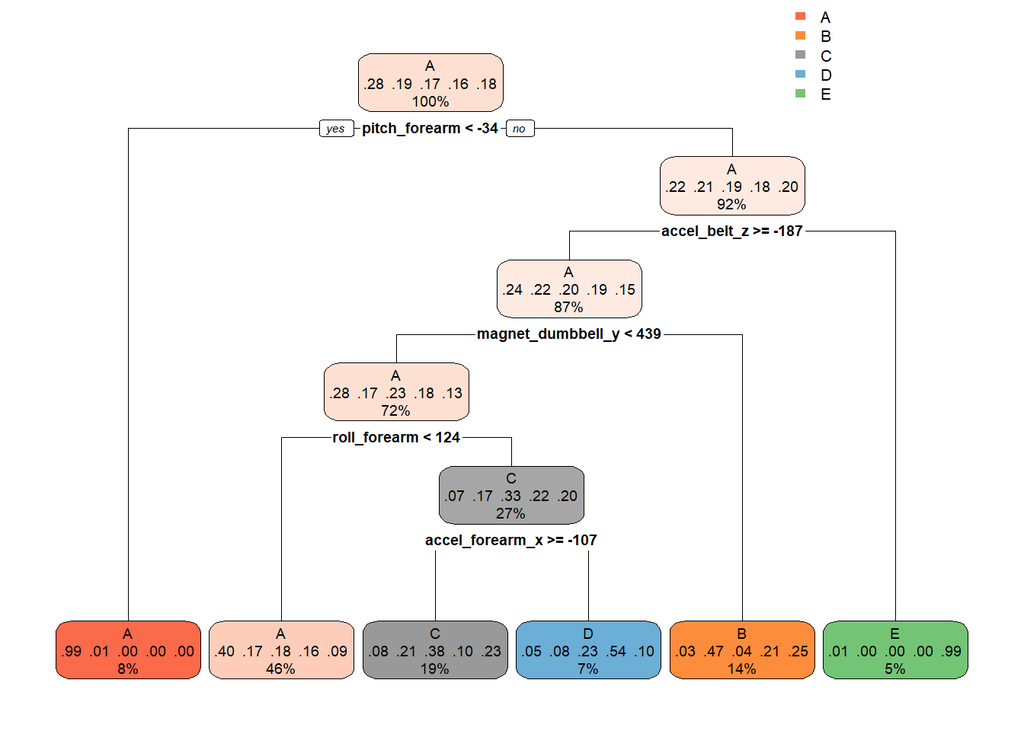

```r
rpart.plot(dtmtrain$finalModel, roundint=FALSE)
```

### Random Forest Model

```r
rfmtrain <- train(classe~., data=trainingset, method="rf", ntree=100)
rfmpredict <- predict(rfmtrain, testingset)
rfmconf <- confusionMatrix(rfmpredict, testingset$classe)
rfmconf
```

```
## Confusion Matrix and Statistics
##
##           Reference
## Prediction    A    B    C    D    E
##          A 2225   13    0    0    0
##          B    6 1488   10    0    2
##          C    1   15 1351   20    0
##          D    0    1    7 1266   11
##          E    0    1    0    0 1429
##
## Overall Statistics
##
##                Accuracy : 0.9889
##                  95% CI : (0.9863, 0.9911)
##     No Information Rate : 0.2845
##     P-Value [Acc > NIR] : < 2.2e-16
##
##                   Kappa : 0.986
##
##  Mcnemar's Test P-Value : NA
##
## Statistics by Class:
##
##                      Class: A Class: B Class: C Class: D Class: E
## Sensitivity            0.9969   0.9802   0.9876   0.9844   0.9910
## Specificity            0.9977   0.9972   0.9944   0.9971   0.9998
## Pos Pred Value         0.9942   0.9880   0.9740   0.9852   0.9993
## Neg Pred Value         0.9988   0.9953   0.9974   0.9970   0.9980
## Prevalence             0.2845   0.1935   0.1744   0.1639   0.1838
## Detection Rate         0.2836   0.1897   0.1722   0.1614   0.1821
## Detection Prevalence   0.2852   0.1919   0.1768   0.1638   0.1823
## Balanced Accuracy      0.9973   0.9887   0.9910   0.9908   0.9954
```

### Gradient Boosting Model

```r
gbmtrain <- train(classe~.,data=trainingset, method="gbm", verbose=FALSE)
gbmpredict <- predict(gbmtrain, testingset)
gbmconf <- confusionMatrix(gbmpredict, testingset$classe)
gbmconf
```

```
## Confusion Matrix and Statistics
##
##           Reference
## Prediction    A    B    C    D    E
##          A 2195   37    0    1    4
##          B   20 1439   46    4   22
##          C   11   41 1300   57   11
##          D    5    0   17 1212   21
##          E    1    1    5   12 1384
##
## Overall Statistics
##
##                Accuracy : 0.9597
##                  95% CI : (0.9551, 0.964)
##     No Information Rate : 0.2845
##     P-Value [Acc > NIR] : < 2.2e-16
##
##                   Kappa : 0.9491
##
##  Mcnemar's Test P-Value : 3.838e-11
##
## Statistics by Class:
##
##                      Class: A Class: B Class: C Class: D Class: E
## Sensitivity            0.9834   0.9480   0.9503   0.9425   0.9598
## Specificity            0.9925   0.9855   0.9815   0.9934   0.9970
## Pos Pred Value         0.9812   0.9399   0.9155   0.9657   0.9865
## Neg Pred Value         0.9934   0.9875   0.9894   0.9888   0.9910
## Prevalence             0.2845   0.1935   0.1744   0.1639   0.1838
## Detection Rate         0.2798   0.1834   0.1657   0.1545   0.1764
## Detection Prevalence   0.2851   0.1951   0.1810   0.1600   0.1788
## Balanced Accuracy      0.9880   0.9667   0.9659   0.9680   0.9784
```

## Conclusion and Final Test

```r
rfmpredictfin <- predict(rfmtrain, testdata2)
rfmpredictfin
```

```
##  [1] B A B A A E D B A A B C B A E E A B B B
## Levels: A B C D E
```